# PREDICTING WHETHER A PERSON IS HOME OR NOT DURING THE DAY TIME

## Task 1

### Task 1.1 : Phase 1 Summary

In Phase 1, I worked with the Smart Grid Smart City dataset, which contains demographic and appliance usage data collected from Australian households. The objective was to understand energy consumption patterns and ultimately predict whether someone is at home during the day (`IsHomeDaytime`).

To begin, I cleaned the dataset by removing irrelevant columns such as identifiers, post-trial administrative dates, and internal codes, as these features were not available at prediction time or added no explanatory value. I handled missing values using a combination of strategies, including grouping by `UnitType` for numerical imputation and filling with mode for categorical variables. Outliers in numerical features like `NumFridges` and `NumHeatedRooms` were capped using the IQR method to avoid dropping valuable rows.

After cleaning, I performed exploratory data analysis (EDA), including single-, two-, and three-variable visualizations. These helped identify important trends such as the relationship between electricity usage and daytime occupancy or climate zone and pool pump ownership.

The cleaned and preprocessed dataset was then saved for use in Phase 2, where I will apply predictive modeling techniques to classify occupancy during the day.

### Task 1.2 : Report Overview

In this Phase 2 report, I build directly on the data preparation and exploratory analyses conducted in Phase 1 to develop, tune, and compare a suite of predictive models for daytime occupancy (`IsHomeDaytime`). The major sections are:

## Task 2

```python
#I am loading all the necessary libraries required for my notebook
import pandas as pd
import numpy as np
import matplotlib.pyplot as plt
import seaborn as sns
from sklearn.pipeline import Pipeline
from sklearn.preprocessing import StandardScaler, OrdinalEncoder
from sklearn.feature_selection import SelectKBest, f_classif
from sklearn.model_selection import (
    train_test_split,
    StratifiedKFold,
    cross_val_score,
    GridSearchCV
)
from sklearn.metrics import (
    accuracy_score,
    classification_report,
    confusion_matrix,
    ConfusionMatrixDisplay,
    roc_auc_score,
    RocCurveDisplay,
    make_scorer
)
from sklearn.linear_model import LogisticRegression
from sklearn.neighbors import KNeighborsClassifier
from sklearn.ensemble import RandomForestClassifier
from sklearn.neural_network import MLPClassifier
from scipy.stats import ttest_rel
import tensorflow as tf
from tensorflow.keras.models import Sequential
from tensorflow.keras.layers import Dense, Dropout
from tensorflow.keras.optimizers import Adam, SGD
```

```python
#I am reading the data that was saved from phase 1 of the notebook
data = pd.read_csv("Phase2_Group6.csv")
```

### Dataset Recap

```python
#Short revisit of the data
data.head(5)
```

|  | ClimateZone | UnitType | GasUse | ElectricityUse | DryerUse | NumFridges | HasGeneration | HasInternet | HasPoolPump | HasAircon | IsHomeDaytime |
| --- | --- | --- | --- | --- | --- | --- | --- | --- | --- | --- | --- |
| 0 | Warm temperate | NotUnit | HI | LOW | LOW | 1.0 | N | Y | Y | Y | Y |
| 1 | Warm temperate | NotUnit | HI | MED | LOW | 2.0 | N | Y | N | Y | N |
| 2 | Warm temperate | NotUnit | LOW | LOW | LOW | 1.0 | N | Y | N | Y | Y |
| 3 | Warm temperate | NotUnit | LOW | MED | NONE | 1.0 | N | Y | N | N | N |
| 4 | Warm temperate | Unit | LOW | LOW | NONE | 1.0 | N | Y | N | N | Y |

```python
target_col = 'IsHomeDaytime'  # ← Change if your target column is named differently
print("Class distribution:")
print(data[target_col].value_counts())
print("\nClass proportions:")
print(data[target_col].value_counts(normalize=True))
```

```
Class distribution:
IsHomeDaytime
Y    12431
N     5940
Name: count, dtype: int64

Class proportions:
IsHomeDaytime
Y    0.676664
N    0.323336
Name: proportion, dtype: float64
```

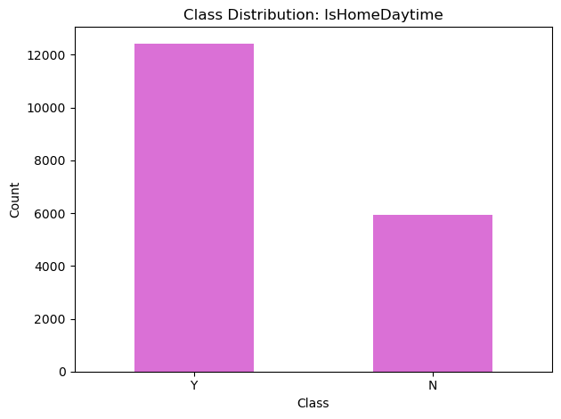

```python
data[target_col].value_counts().plot(kind='bar', color='orchid')
plt.title(f"Class Distribution: {target_col}")
plt.xlabel("Class")
plt.ylabel("Count")
plt.xticks(rotation=0)
plt.tight_layout()
plt.show()
```

```python
print(data.info())
```

```
<class 'pandas.core.frame.DataFrame'>
RangeIndex: 18371 entries, 0 to 18370
Data columns (total 11 columns):
 #   Column          Non-Null Count  Dtype
---  ------          --------------  -----
 0   ClimateZone     18371 non-null  object
 1   UnitType        18371 non-null  object
 2   GasUse          18371 non-null  object
 3   ElectricityUse  18371 non-null  object
 4   DryerUse        18371 non-null  object
 5   NumFridges      18371 non-null  float64
 6   HasGeneration   18371 non-null  object
 7   HasInternet     18371 non-null  object
 8   HasPoolPump     18371 non-null  object
 9   HasAircon       18371 non-null  object
 10  IsHomeDaytime   18371 non-null  object
dtypes: float64(1), object(10)
memory usage: 1.5+ MB
None
```

```python
#Mapping the target variable
data["IsHomeDaytime"] = data["IsHomeDaytime"].map({'Y': 1, 'N': 0})
y = data["IsHomeDaytime"]
```

### Feature Encoding

```python
#I am performing feature encoding for certain features in the dataset for easier training of the models
numeric_cols = ["NumFridges"]
ordinal_cols = ["GasUse", "ElectricityUse", "DryerUse"]
nominal_cols = ["ClimateZone", "UnitType", "HasGeneration", "HasInternet", "HasPoolPump", "HasAircon"]

X_num = data[numeric_cols].copy()
X_ord = data[ordinal_cols].copy()
X_nom = data[nominal_cols].copy()
```

```python
ord_categories = [
    ["NONE", "LOW", "MED", "HI"],
    ["NONE", "LOW", "MED", "HI"],
    ["NONE", "LOW", "MED", "HI"],
]
ord_enc = OrdinalEncoder(categories=ord_categories)
X_ord_enc = pd.DataFrame(
    ord_enc.fit_transform(X_ord),
    columns=ordinal_cols,
    index=data.index
)
```

```python
X_nom_enc = pd.get_dummies(
    X_nom,
    columns=nominal_cols,
    prefix=nominal_cols,
    drop_first=False,
    dtype=int
)
```

```python
X_encoded = pd.concat([X_num, X_ord_enc, X_nom_enc], axis=1)
print(X_encoded.head())
```

```
   NumFridges  GasUse  ElectricityUse  DryerUse  ClimateZone_Mild temperate  \
0         1.0     3.0             1.0       1.0                           0
1         2.0     3.0             2.0       1.0                           0
2         1.0     1.0             1.0       1.0                           0
3         1.0     1.0             2.0       0.0                           0
4         1.0     1.0             1.0       0.0                           0

   ClimateZone_Warm temperate  UnitType_NotUnit  UnitType_Unit  \
0                           1                 1              0
1                           1                 1              0
2                           1                 1              0
3                           1                 1              0
4                           1                 0              1

   HasGeneration_N  HasGeneration_Y  HasInternet_N  HasInternet_Y  \
0                1                0              0              1
1                1                0              0              1
2                1                0              0              1
3                1                0              0              1
4                1                0              0              1

   HasPoolPump_N  HasPoolPump_Y  HasAircon_N  HasAircon_Y
0              0              1            0            1
1              1              0            0            1
2              1              0            0            1
3              1              0            1            0
4              1              0            1            0
```

To prepare the dataset for machine learning, I categorized the input features into three types based on their semantics and data types:

- **Numeric features**: These include continuous or count-based variables. In this case, `NumFridges` was treated as a numeric feature since it represents a count of household appliances and does not require encoding.
- **Ordinal features**: These are categorical features with an inherent order. I identified `GasUse`, `ElectricityUse`, and `DryerUse` as ordinal variables, each with levels: `NONE`, `LOW`, `MED`, and `HI`. I used `OrdinalEncoder` with predefined category ordering to transform them into integer values (e.g., `NONE` = 0, `HI` = 3). This preserves the ranking information, which is valuable for tree-based and linear models.
- **Nominal features**: These features have no intrinsic ordering and include variables such as `ClimateZone`, `UnitType`, `HasGeneration`, `HasInternet`, `HasPoolPump`, and `HasAircon`. For these, I applied one-hot encoding using `pd.get_dummies()` without dropping the first category (`drop_first=False`) to retain full representation of all categories. This is especially useful when model interpretability is important or when each category carries distinct behavior.

This transformation process ensures that the model can effectively interpret and learn from all available features:

- **Ordinal encoding preserves order** for ranked features, allowing models to infer intensity or usage levels.
- **One-hot encoding prevents misinterpretation** of nominal data by not imposing any artificial order.
- **Combining these encoded features into a unified dataset** enables consistent model training, supports diverse algorithms, and ensures fair treatment of categorical variables.

Overall, this preprocessing pipeline improves both the **performance and interpretability** of subsequent models, especially in understanding the influence of lifestyle, appliance ownership, and household infrastructure on daytime occupancy.

### 2.1 Feature Selection

```python
selector = SelectKBest(score_func=f_classif, k=10)
X_sel = selector.fit_transform(X_encoded, y)
selected_feats = X_encoded.columns[selector.get_support()].tolist()
print("Selected features:", selected_feats)
```

```
Selected features: ['NumFridges', 'GasUse', 'UnitType_NotUnit', 'UnitType_Unit', 'HasInternet_N', 'HasInternet_Y', 'HasPoolPump_N', 'HasPoolPump_Y', 'HasAircon_N', 'HasAircon_Y']
```

To enhance model performance and interpretability, I performed feature selection using **`SelectKBest`** from the `sklearn.feature_selection` module. Feature selection helps reduce noise, prevent overfitting, and speed up training by retaining only the most informative input variables.

For this task, I used the **`f_classif`** scoring function, which applies the **ANOVA F-test** to each feature in relation to the target variable. This statistical test measures the **linear dependency between each feature and the binary class labels** (`IsHomeDaytime = 0 or 1`). Features with **higher F-scores** indicate greater discriminatory power — i.e., they better explain the variance between the two classes.

The `SelectKBest` method ranks all input features based on their F-scores and selects the **top 10** features with the highest scores:

1. **NumFridges**

The number of refrigerators in a household can act as a proxy for both **household size** and **food storage behavior**. Larger families tend to require more food storage capacity and may own multiple fridges. This typically suggests greater domestic activity and a higher likelihood of someone being home during the day — for cooking, childcare, or household management. Additionally, individuals who work from home or follow flexible routines may prefer to stock up on groceries and prepare meals during the day, reinforcing this association.

2. **GasUse**

This variable reflects overall gas consumption, including **cooking, space heating, and water heating**. High gas usage may suggest **frequent at-home activity**, particularly cooking during lunch hours, which strongly correlates with daytime presence. Conversely, low gas usage might indicate the household is empty for extended periods or that meals are not prepared at home — suggesting daytime absence. Even moderate gas use could reflect consistent but brief periods of presence.

3. **UnitType_NotUnit / UnitType_Unit**

The type of dwelling influences occupancy patterns. Households in **“units” (apartments)** may consist of younger individuals, students, or working professionals, many of whom follow a traditional 9-to-5 schedule — implying lower daytime presence. In contrast, **standalone houses** are often occupied by families or retirees, who are **more likely to be home during the day**. Thus, dwelling type encodes both **infrastructure** and **demographic/lifestyle** differences.

4. **HasInternet_N / HasInternet_Y**

Internet access often reflects **digital engagement** and **home-centered routines**. With the rise of **remote work, online education, and streaming**, internet availability increases the odds that someone is present at home during the day. Conversely, households without internet may include individuals with more traditional work routines or lower socio-economic status, making daytime presence less likely.

5. **HasPoolPump_N / HasPoolPump_Y**

The presence of a pool pump is typically associated with **detached homes** in suburban or higher-income areas. Pool ownership implies the need for **regular maintenance** — either by residents or external providers — and use during the day, especially in warm climates. This reflects **leisure or family-oriented households** where someone may frequently be home to manage or enjoy such amenities.

6. **HasAircon_N / HasAircon_Y**

Air conditioning is a particularly relevant feature in **warmer climate zones**, where residents are more likely to stay indoors during peak heat hours. Occupants with air conditioning may follow **comfort-driven routines**, including working or relaxing at home. This can be a **proxy for climate-influenced occupancy behavior** and is particularly useful for distinguishing regional lifestyle differences.

These 10 features span across **appliance usage**, **dwelling structure**, and **household amenities**. Together, they help create a well-rounded behavioral and environmental profile, supporting the predictive task of determining **daytime occupancy** with both logical and empirical backing.

### 2.2 Model Fitting & Tuning:

#### 2.2.1. Logistic Regression

##### 2.2.1.1 Logisitic Regression without penalty

```python
#Spliting training and test data from the selected features using stratification to maintain balance
X_train_selected, X_test_selected, y_train, y_test = train_test_split(
    X_sel, y, stratify=y, random_state=42
)
```

```python
#Ensuring there is equal division of data in terms of training and testing
print("Proportion of class 1 in training set:", (y_train == 1).mean())
print("Proportion of class 1 in test set:    ", (y_test == 1).mean())
```

```
Proportion of class 1 in training set: 0.6766584409928872
Proportion of class 1 in test set:     0.6766819072501633
```

```python
print("Proportion of class 1 in training set:", (y_train == 0).mean())
print("Proportion of class 1 in test set:    ", (y_test == 0).mean())
```

```
Proportion of class 1 in training set: 0.3233415590071128
Proportion of class 1 in test set:     0.3233180927498367
```

```python
#Logistic Regression without penalty
logisticregression = LogisticRegression(
    solver='lbfgs',
    max_iter=1000,
    random_state=42
)
logisticregression.fit(X_train_selected, y_train)
```

```
LogisticRegression(max_iter=1000, random_state=42)
```

```python
y_pred = logisticregression.predict(X_test_selected)
y_proba = logisticregression.predict_proba(X_test_selected)[:, 1]
```

```python
print("\n Logistic Regression (No Penalty) Accuracy:", logisticregression.score(X_test_selected, y_test))
print("\n Classification Report (No Penalty):\n", classification_report(y_test, y_pred))
```

```
 Logistic Regression (No Penalty) Accuracy: 0.7012845634661441

 Classification Report (No Penalty):
               precision    recall  f1-score   support

           0       0.56      0.35      0.43      1485
           1       0.74      0.87      0.80      3108

    accuracy                           0.70      4593
   macro avg       0.65      0.61      0.61      4593
weighted avg       0.68      0.70      0.68      4593
```

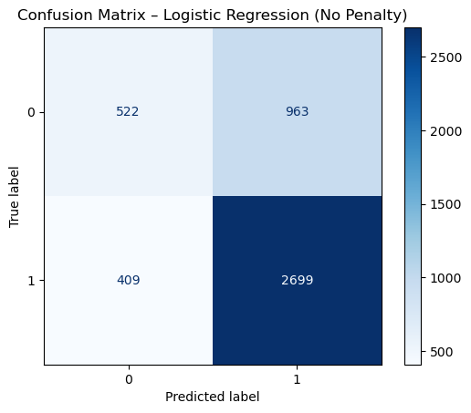

```python
cm = confusion_matrix(y_test, y_pred)
disp = ConfusionMatrixDisplay(confusion_matrix=cm, display_labels=logisticregression.classes_)
disp.plot(cmap='Blues')
plt.title("Confusion Matrix – Logistic Regression (No Penalty)")
plt.grid(False)
plt.show()
```

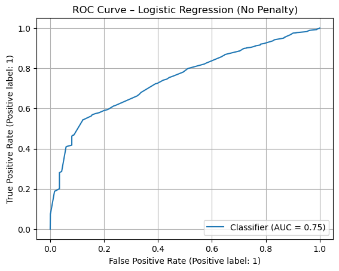

```
 ROC-AUC Score (No Penalty): 0.7458861458861459
```

```python
RocCurveDisplay.from_predictions(y_test, y_proba)
plt.title("ROC Curve – Logistic Regression (No Penalty)")
plt.grid(True)
plt.show()

print(" ROC-AUC Score (No Penalty):", roc_auc_score(y_test, y_proba))
```

##### 2.2.1.2 Logistic Regression with penalty

```python
logreg_l2 = LogisticRegression(
    penalty="l2",
    solver="lbfgs",
    max_iter=1000,
    random_state=42
)
logreg_l2.fit(X_train_selected, y_train)
```

```
LogisticRegression(max_iter=1000, random_state=42)
```

```python
y_pred = logreg_l2.predict(X_test_selected)
```

```python
print("\n Logistic Regression (L2 penalty) Accuracy:", logreg_l2.score(X_test_selected, y_test))
print("\n Classification Report (L2 penalty):\n", classification_report(y_test, y_pred))
```

```
 Logistic Regression (L2 penalty) Accuracy: 0.7012845634661441

 Classification Report (L2 penalty):
               precision    recall  f1-score   support

           0       0.56      0.35      0.43      1485
           1       0.74      0.87      0.80      3108

    accuracy                           0.70      4593
   macro avg       0.65      0.61      0.61      4593
weighted avg       0.68      0.70      0.68      4593
```

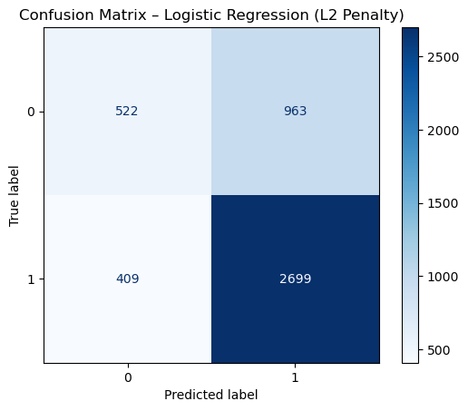

```python
cm = confusion_matrix(y_test, y_pred)
disp = ConfusionMatrixDisplay(confusion_matrix=cm, display_labels=logreg_l2.classes_)
disp.plot(cmap='Blues')
plt.title("Confusion Matrix – Logistic Regression (L2 Penalty)")
plt.grid(False)
plt.show()
```

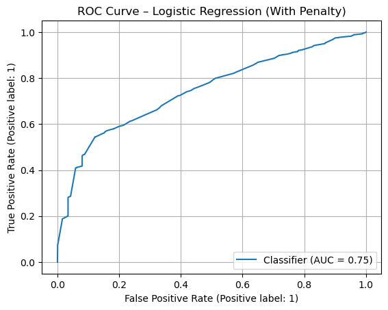

```
 ROC-AUC Score (No Penalty): 0.7458861458861459
```

```python
RocCurveDisplay.from_predictions(y_test, y_proba)
plt.title("ROC Curve – Logistic Regression (With Penalty)")
plt.grid(True)
plt.show()

print(" ROC-AUC Score (No Penalty):", roc_auc_score(y_test, y_proba))
```

##### Logistic Regression: Performance Interpretation

The Logistic Regression model achieved an overall **accuracy of 70%**, but more importantly, it delivered strong performance on the class of primary interest — identifying when someone is **at home during the daytime** (`IsHomeDaytime = 1`). This outcome is central to the project’s objective of supporting **intelligent energy management**, where accurately detecting presence allows for optimized control of heating, cooling, lighting, and other appliances.

The model achieved a **recall of 87%** for class 1, meaning it correctly identified **2,699 out of 3,108** truly "at home" households in the test set. This high recall is crucial because **missing an occupied household** (a false negative) could result in deactivating comfort-related systems when someone is actually home, leading to **user discomfort or dissatisfaction**. Therefore, recall for class 1 is the **most important metric** for this use case, and the model performs **very well** in this regard.

In contrast, the **recall for class 0** (households not at home) was only **35%**, with the model correctly identifying **522 out of 1,485** unoccupied instances. This shows a significant number of **false positives**, where the model incorrectly predicted that someone was home. However, in this context, these errors are **less damaging** — they might lead to **minor energy inefficiencies** (e.g., keeping systems on unnecessarily), but they do **not compromise comfort or safety**. Hence, this shortcoming is acceptable given the trade-off in favor of recall for the more critical class.

The **F1-score for class 1** was **0.80**, reflecting a strong balance between precision (**74%**) and recall (**87%**) for the "home" class. This makes the model robust for deployment scenarios where **ensuring presence detection** is prioritized, while tolerating some false positives.

Lastly, I assessed the model’s discriminative power using the **ROC curve**. Both versions of the model — with and without regularization — achieved a consistent **ROC-AUC score of 0.75**. This indicates good separation between the two classes across all thresholds, and it supports the earlier conclusion that the model is reliable for identifying daytime occupancy.

#### 2.2.2 KNN Classifier

##### 2.2.2.1 KNN Classifier without hyperparameter tuning

```python
knn_default = KNeighborsClassifier()
knn_default.fit(X_train_selected, y_train)
```

```
KNeighborsClassifier()
```

```python
y_pred_default = knn_default.predict(X_test_selected)
y_proba_default = knn_default.predict_proba(X_test_selected)[:, 1]
```

```python
print("\n Classification Report (Default KNN):\n", classification_report(y_test, y_pred_default))
print(" ROC-AUC Score (Default KNN):", roc_auc_score(y_test, y_proba_default))
```

```
 Classification Report (Default KNN):
               precision    recall  f1-score   support

           0       0.53      0.50      0.51      1485
           1       0.77      0.79      0.78      3108

    accuracy                           0.69      4593
   macro avg       0.65      0.64      0.64      4593
weighted avg       0.69      0.69      0.69      4593

 ROC-AUC Score (Default KNN): 0.7345390845390846
```

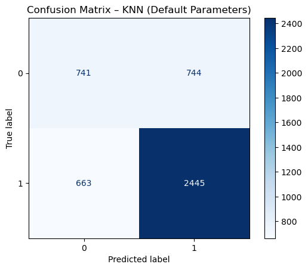

```python
cm = confusion_matrix(y_test, y_pred_default)
disp = ConfusionMatrixDisplay(confusion_matrix=cm, display_labels=knn_default.classes_)
disp.plot(cmap='Blues')
plt.title("Confusion Matrix – KNN (Default Parameters)")
plt.grid(False)
plt.show()
```

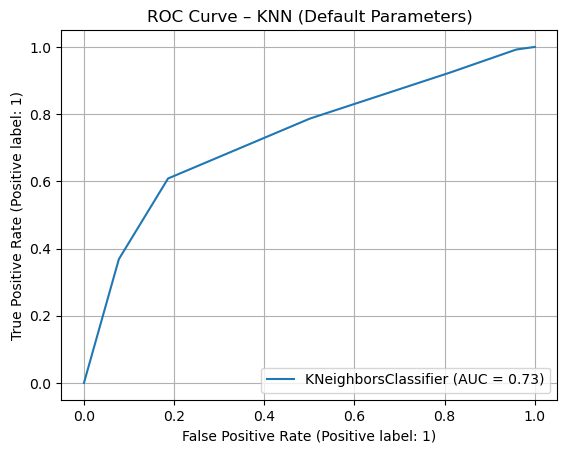

```python
RocCurveDisplay.from_estimator(knn_default, X_test_selected, y_test)
plt.title("ROC Curve – KNN (Default Parameters)")
plt.grid(True)
plt.show()
```

##### KNN (Without Tuning) - Interpretation:

The default **K-Nearest Neighbors (KNN)** classifier achieved an overall **accuracy of 69%**, demonstrating reasonable performance for predicting whether someone is at home during the day (`IsHomeDaytime = 1`). As the primary objective of this project is to support intelligent energy management through occupancy detection, the model’s ability to correctly identify when someone is home — especially in terms of recall for class 1 — is of critical importance.

The model achieved a **recall of 79%** for class 1, successfully identifying **2,445 out of 3,108** occupied households. This high recall is valuable because failing to detect an occupied home (a false negative) could lead to comfort-related systems like heating, lighting, or cooling being incorrectly turned off. Therefore, a high recall for class 1 ensures that user comfort is preserved, making it the most important metric in this context.

However, the model's **recall for class 0** (not at home) was only **50%**, indicating that it correctly identified **741 out of 1,485** unoccupied homes. The remaining **744 unoccupied homes were misclassified as occupied** (false positives), and **663 occupied homes were missed** (false negatives). This confusion matrix suggests that the model is somewhat biased toward predicting presence, which is acceptable given the application. False positives may lead to minor energy inefficiencies — such as running appliances unnecessarily — but do not compromise user experience. In contrast, false negatives could negatively affect comfort, which the model successfully minimizes.

The **F1-score for class 1** was **0.78**, indicating a strong balance between **precision (0.77)** and **recall (0.79)** for detecting presence. The **ROC-AUC score of 0.73** further confirms the model’s moderate discriminatory power between the two classes. Since this model was built using default hyperparameters (`n_neighbors=5`, `weights='uniform'`, `p=2`), there is potential to further improve its performance — especially recall for class 0 — through hyperparameter tuning.

##### 2.2.2.2 KNN Classifier with parameter tuning

```python
cv_method = StratifiedKFold(n_splits=5, shuffle=True, random_state=999)
knn_model = KNeighborsClassifier()
knn_params = {
    'n_neighbors': [1, 3, 5, 10, 15, 20],
    'p': [1, 2, 3, 4, 5]
}
grid_search = GridSearchCV(
    estimator=knn_model,
    param_grid=knn_params,
    scoring="roc_auc",
    cv=cv_method
)
grid_search.fit(X_train_selected, y_train)
```

```
GridSearchCV(cv=StratifiedKFold(n_splits=5, random_state=999, shuffle=True),
             estimator=KNeighborsClassifier(),
             param_grid={'n_neighbors': [1, 3, 5, 10, 15, 20],
                         'p': [1, 2, 3, 4, 5]},
             scoring='roc_auc')
```

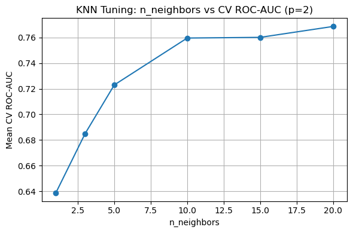

```python
knn_results = pd.DataFrame(grid_search.cv_results_)
knn_sub = knn_results[knn_results['param_p'] == 2]

plt.figure(figsize=(6,4))
plt.plot(
    knn_sub['param_n_neighbors'].astype(int),
    knn_sub['mean_test_score'],
    marker='o'
)
plt.title('KNN Tuning: n_neighbors vs CV ROC-AUC (p=2)')
plt.xlabel('n_neighbors')
plt.ylabel('Mean CV ROC-AUC')
plt.grid(True)
plt.tight_layout()
plt.show()
```

```python
best_knn = grid_search.best_estimator_
y_pred_best = best_knn.predict(X_test_selected)
y_proba_best = best_knn.predict_proba(X_test_selected)[:, 1]
test_auc_best = roc_auc_score(y_test, y_proba_best)
```

```python
best_knn = grid_search.best_estimator_
y_pred_best = best_knn.predict(X_test_selected)
y_proba_best = best_knn.predict_proba(X_test_selected)[:, 1]
test_auc_best = roc_auc_score(y_test, y_proba_best)
```

```python
print(" Best Estimator:\n", best_knn)
print(" Best Parameters:", grid_search.best_params_)
print(" Best CV ROC-AUC:", grid_search.best_score_)
print(" Test ROC-AUC (Tuned KNN):", test_auc_best)
print(" Classification Report (Tuned KNN):\n", classification_report(y_test, y_pred_best))
```

```
 Best Estimator:
 KNeighborsClassifier(n_neighbors=20)
 Best Parameters: {'n_neighbors': 20, 'p': 2}
 Best CV ROC-AUC: 0.7686706048197092
 Test ROC-AUC (Tuned KNN): 0.7741606324939657
 Classification Report (Tuned KNN):
               precision    recall  f1-score   support

           0       0.53      0.64      0.58      1485
           1       0.81      0.73      0.77      3108

    accuracy                           0.70      4593
   macro avg       0.67      0.68      0.67      4593
weighted avg       0.72      0.70      0.71      4593
```

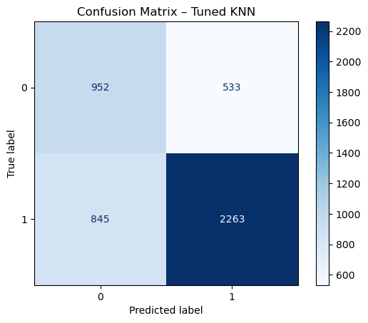

```python
cm = confusion_matrix(y_test, y_pred_best)
disp = ConfusionMatrixDisplay(confusion_matrix=cm, display_labels=best_knn.classes_)
disp.plot(cmap='Blues')
plt.title("Confusion Matrix – Tuned KNN")
plt.grid(False)
plt.show()
```

##### KNN (Parameter tuning) - Interpretation

After performing hyperparameter tuning using `GridSearchCV` with a 5-fold `StratifiedKFold` cross-validation strategy, the optimal KNN configuration was found to be **`n_neighbors=20`** with **`p=2`** (Euclidean distance). This tuned model achieved a **cross-validated ROC-AUC of 0.7687** and a **test ROC-AUC of 0.7742**, reflecting improved class separation compared to the default KNN setup.

The **F1-score for class 1** was **0.77**, and the **macro-averaged F1-score** reached **0.67**, showing improved balance between classes. The **weighted average F1-score** was **0.71**, highlighting the model’s overall robustness.

##### 2.2.2.3 KNN Tuning with weights

```python
cv_method = StratifiedKFold(n_splits=5, shuffle=True, random_state=999)
knn_model_weighted = KNeighborsClassifier()
knn_params_weighted = {
    'n_neighbors': [1, 3, 5, 10, 15, 20],
    'p': [1, 2, 3, 4, 5],
    'weights': ['uniform', 'distance']
}
grid_search_weighted = GridSearchCV(
    estimator=knn_model_weighted,
    param_grid=knn_params_weighted,
    scoring="roc_auc",
    cv=cv_method,
    n_jobs=-1
)
grid_search_weighted.fit(X_train_selected, y_train)
```

```
GridSearchCV(cv=StratifiedKFold(n_splits=5, random_state=999, shuffle=True),
             estimator=KNeighborsClassifier(), n_jobs=-1,
             param_grid={'n_neighbors': [1, 3, 5, 10, 15, 20],
                         'p': [1, 2, 3, 4, 5],
                         'weights': ['uniform', 'distance']},
             scoring='roc_auc')
```

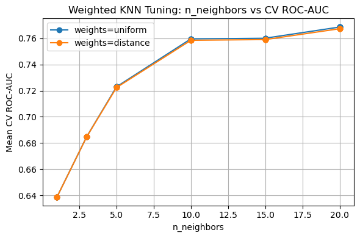

```python
wknn_results = pd.DataFrame(grid_search_weighted.cv_results_)

plt.figure(figsize=(6,4))
for weight in ['uniform','distance']:
    sub = wknn_results[wknn_results['param_weights'] == weight]
    plt.plot(
        sub['param_n_neighbors'].astype(int),
        sub['mean_test_score'],
        marker='o',
        label=f'weights={weight}'
    )
plt.title('Weighted KNN Tuning: n_neighbors vs CV ROC-AUC')
plt.xlabel('n_neighbors')
plt.ylabel('Mean CV ROC-AUC')
plt.legend()
plt.grid(True)
plt.tight_layout()
plt.show()
```

```python
best_knn_weighted = grid_search_weighted.best_estimator_
y_pred_weighted = best_knn_weighted.predict(X_test_selected)
y_proba_weighted = best_knn_weighted.predict_proba(X_test_selected)[:, 1]
test_auc_weighted = roc_auc_score(y_test, y_proba_weighted)
```

```python
print("Best Estimator (Weighted KNN):\n", best_knn_weighted)
print("Best Parameters:", grid_search_weighted.best_params_)
print("Best CV ROC-AUC:", grid_search_weighted.best_score_)
print("Test ROC-AUC (Weighted KNN):", test_auc_weighted)
print("Classification Report:\n", classification_report(y_test, y_pred_weighted))
```

```
Best Estimator (Weighted KNN):
 KNeighborsClassifier(n_neighbors=20)
Best Parameters: {'n_neighbors': 20, 'p': 2, 'weights': 'uniform'}
Best CV ROC-AUC: 0.7686706048197092
Test ROC-AUC (Weighted KNN): 0.7741606324939657
Classification Report:
               precision    recall  f1-score   support

           0       0.53      0.64      0.58      1485
           1       0.81      0.73      0.77      3108

    accuracy                           0.70      4593
   macro avg       0.67      0.68      0.67      4593
weighted avg       0.72      0.70      0.71      4593
```

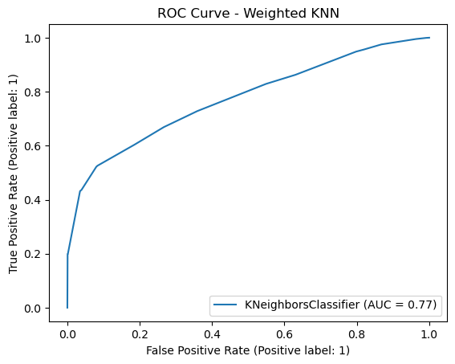

```python
RocCurveDisplay.from_estimator(best_knn_weighted, X_test_selected, y_test)
plt.title("ROC Curve - Weighted KNN")
plt.show()
```

##### KNN (with weight tuning) - Interpretation

I extended the KNN tuning process to further improve classification performance to include the `weights` hyperparameter. Specifically, I compared uniform weights (each neighbor contributes equally) with distance-based weighting (closer neighbors have more influence). The best configuration remained at **`n_neighbors=20`**, with **`p=2`** (Euclidean distance) and **`weights='uniform'`**, as determined via `GridSearchCV` with 5-fold `StratifiedKFold`. This setup achieved a **cross-validated ROC-AUC of 0.7687** and a **test ROC-AUC of 0.7742**, exactly matching the results of the unweighted tuned KNN, indicating that **weighting did not lead to further performance gains**.

The **F1-score for class 1** was **0.77**, with macro and weighted F1-scores of **0.67** and **0.71**, respectively, showing balanced performance across classes. The similarity in scores between the weighted and unweighted versions of tuned KNN suggests that **in this dataset, distance-based weighting does not provide a measurable advantage** over uniform weights, likely due to the well-separated nature of the selected features after preprocessing.

#### 2.2.3. Random Forest Classifier

##### 2.2.3.1 Default Random Forest Classifier

```python
rf_default = RandomForestClassifier(random_state=42)
rf_default.fit(X_train_selected, y_train)
```

```
RandomForestClassifier(random_state=42)
```

```python
y_pred_rf_default = rf_default.predict(X_test_selected)
y_proba_rf_default = rf_default.predict_proba(X_test_selected)[:, 1]
```

```python
print(" Classification Report (Default RF):\n", classification_report(y_test, y_pred_rf_default))
print(" ROC-AUC (Default RF):", roc_auc_score(y_test, y_proba_rf_default))
```

```
 Classification Report (Default RF):
               precision    recall  f1-score   support

           0       0.59      0.44      0.51      1485
           1       0.76      0.86      0.81      3108

    accuracy                           0.72      4593
   macro avg       0.68      0.65      0.66      4593
weighted avg       0.71      0.72      0.71      4593

 ROC-AUC (Default RF): 0.786348469681803
```

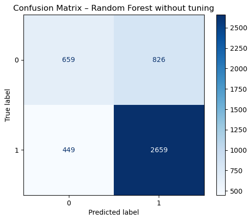

```python
cm = confusion_matrix(y_test, y_pred_rf_default)
disp = ConfusionMatrixDisplay(confusion_matrix=cm, display_labels=rf_default.classes_)
disp.plot(cmap='Blues')
plt.title("Confusion Matrix – Random Forest without tuning")
plt.grid(False)
plt.show()
```

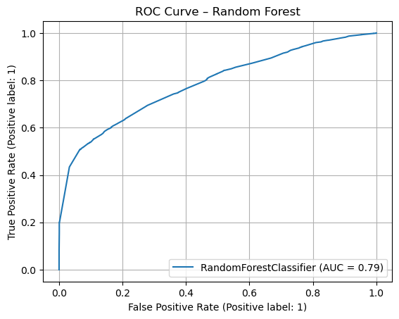

```python
RocCurveDisplay.from_estimator(rf_default, X_test_selected, y_test)
plt.title("ROC Curve – Random Forest")
plt.grid(True)
plt.show()
```

The **Random Forest classifier**, applied **without any hyperparameter tuning**, achieved an overall **accuracy of 72%** and a **ROC-AUC score of 0.7863**, making it the **strongest performing model so far** in terms of its ability to distinguish between households that are **occupied and unoccupied during the daytime**.

The model excelled in detecting presence (**IsHomeDaytime = 1**), which is the **key objective** of this project. It achieved a **recall of 86%** and a **precision of 76%** for class 1, correctly identifying **2,659 out of 3,108** homes that were truly occupied. This **high recall** is essential because it ensures that households where people are present during the day are recognized correctly, allowing energy systems like **lighting, heating, or cooling** to remain active — directly contributing to **user comfort and satisfaction**.

On the other hand, the model’s **recall for class 0** (unoccupied homes) was **44%**, meaning that it correctly identified **659 out of 1,485** households that were actually not home. Although this suggests a **considerable number of false positives** (i.e., predicting someone is home when they are not), the impact of these misclassifications is **relatively minor** in this context. Such errors may lead to **slightly higher energy usage** but do not negatively affect **user experience or comfort**.

The **F1-score for class 1** was **0.81**, reflecting a strong **trade-off between precision and recall**, and the **macro-averaged F1-score** was **0.66**, which indicates **decent overall balance** across both classes.

The confusion matrix reveals that the model correctly identified **659** households as not occupied (**true negatives**) and **2,659** households as occupied (**true positives**). However, it also produced **826 false positives**—predicting a household was occupied when it wasn’t—and **449 false negatives**, where occupied homes were missed. These figures demonstrate the model’s tendency to **prioritize correctly identifying when people are home**, even at the expense of **overpredicting presence**. Given the project's primary objective of **minimizing user discomfort due to missed occupancy**, this trade-off is **acceptable** and, in many practical cases, **desirable**, as false positives only lead to marginally higher energy usage rather than affecting user comfort.

##### 2.2.3.2 Random Forest Classifier with parameter tuning

```python
cv_method = StratifiedKFold(n_splits=5, shuffle=True, random_state=999)
rf_model = RandomForestClassifier(random_state=42)
rf_params = {
    'n_estimators': [100, 200],
    'max_depth': [None, 5, 10, 20],
    'min_samples_split': [2, 5, 10]
}
grid_search_rf = GridSearchCV(
    estimator=rf_model,
    param_grid=rf_params,
    scoring='roc_auc',
    cv=cv_method,
    n_jobs=-1
)
grid_search_rf.fit(X_train_selected, y_train)
```

```
GridSearchCV(cv=StratifiedKFold(n_splits=5, random_state=999, shuffle=True),
             estimator=RandomForestClassifier(random_state=42), n_jobs=-1,
             param_grid={'max_depth': [None, 5, 10, 20],
                         'min_samples_split': [2, 5, 10],
                         'n_estimators': [100, 200]},
             scoring='roc_auc')
```

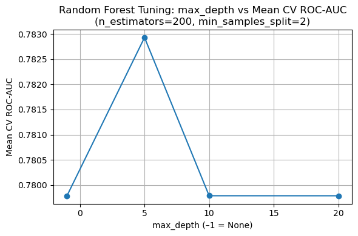

```python
rf_results = pd.DataFrame(grid_search_rf.cv_results_)
rf_sub = rf_results[
    (rf_results['param_n_estimators'] == 200) &
    (rf_results['param_min_samples_split'] == 2)
].copy()

rf_sub['max_depth_plot'] = rf_sub['param_max_depth'].apply(lambda x: -1 if x is None else int(x))

plt.figure(figsize=(6,4))
plt.plot(
    rf_sub['max_depth_plot'],
    rf_sub['mean_test_score'],
    marker='o'
)
plt.title('Random Forest Tuning: max_depth vs Mean CV ROC-AUC\n(n_estimators=200, min_samples_split=2)')
plt.xlabel('max_depth (–1 = None)')
plt.ylabel('Mean CV ROC-AUC')
plt.grid(True)
plt.tight_layout()
plt.show()
```

```python
best_rf = grid_search_rf.best_estimator_
y_pred_rf_best = best_rf.predict(X_test_selected)
y_proba_rf_best = best_rf.predict_proba(X_test_selected)[:, 1]
```

```python
print(" Best Estimator (Tuned RF):\n", best_rf)
print(" Best Parameters:", grid_search_rf.best_params_)
print(" Best CV ROC-AUC:", grid_search_rf.best_score_)
print(" Test ROC-AUC (Tuned RF):", roc_auc_score(y_test, y_proba_rf_best))
print(" Classification Report (Tuned RF):\n", classification_report(y_test, y_pred_rf_best))
```

```
 Best Estimator (Tuned RF):
 RandomForestClassifier(max_depth=5, n_estimators=200, random_state=42)
 Best Parameters: {'max_depth': 5, 'min_samples_split': 2, 'n_estimators': 200}
 Best CV ROC-AUC: 0.7829303797634275
 Test ROC-AUC (Tuned RF): 0.7825045825045824
 Classification Report (Tuned RF):
               precision    recall  f1-score   support

           0       0.59      0.37      0.46      1485
           1       0.74      0.88      0.81      3108

    accuracy                           0.71      4593
   macro avg       0.67      0.62      0.63      4593
weighted avg       0.70      0.71      0.69      4593
```

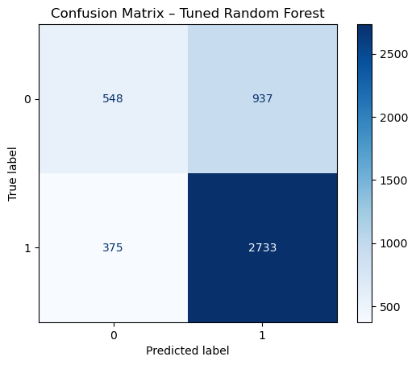

```python
cm = confusion_matrix(y_test, y_pred_rf_best)
disp = ConfusionMatrixDisplay(confusion_matrix=cm, display_labels=best_rf.classes_)
disp.plot(cmap='Blues')
plt.title("Confusion Matrix – Tuned Random Forest")
plt.grid(False)
plt.show()
```

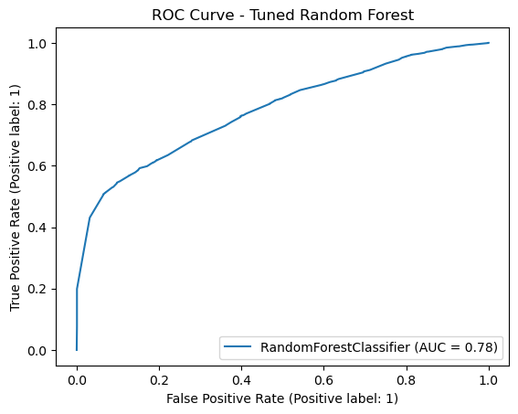

```python
RocCurveDisplay.from_estimator(best_rf, X_test_selected, y_test)
plt.title("ROC Curve - Tuned Random Forest")
plt.show()
```

##### Random Forest Classifier (with tuning) - Interpretation:

After performing hyperparameter tuning, the Random Forest model was configured with a maximum depth of **5** and **200 estimators**, using the best parameters found through grid search: `{'max_depth': 5, 'min_samples_split': 2, 'n_estimators': 200}`. This version of the model aimed to improve generalization and reduce overfitting compared to the default version. The best cross-validation ROC-AUC score was **0.7829**, and on the test set, the model achieved a similar **ROC-AUC score of 0.7825**, indicating strong and stable performance.

The classification report shows that the model achieved an overall **accuracy of 71%**. For **class 1 (occupied households)**, which is the primary focus of this project, the model performed particularly well with a **precision of 74%**, a **recall of 88%**, and an **F1-score of 0.81**. This indicates that the tuned model is highly effective in correctly identifying when homes are occupied during the daytime. On the other hand, for **class 0 (unoccupied households)**, the model achieved a **precision of 59%**, a **recall of 37%**, and an **F1-score of 0.46**. The relatively low recall for class 0 suggests that the model still tends to overpredict occupancy, which is an acceptable trade-off in this scenario given the project's objective.

The confusion matrix supports this trend, showing **2,733 true positives** and **375 false negatives** for class 1, as well as **548 true negatives** and **937 false positives** for class 0. This indicates that while the model does misclassify some unoccupied homes as occupied, it rarely misses homes that are actually occupied. In total, the macro-averaged F1-score was **0.63**, and the weighted F1-score was **0.69**, reflecting a decent balance across both classes while prioritizing the detection of presence.

The ROC curve for the tuned model yielded an area under the curve (AUC) of **0.78**, confirming that the model performs well in distinguishing between the two classes. This value, along with the strong recall for class 1, further validates that the tuned model is aligned with the real-world needs of the system — namely, ensuring that **occupied homes are correctly detected so that energy systems can remain active**, thus maintaining user comfort.

In conclusion, the **tuned Random Forest classifier** offers reliable performance, with strong recall on the target class and a high AUC score, even when using a relatively shallow tree structure. While the number of false positives remains high, this trade-off is acceptable because it avoids the more disruptive consequence of failing to detect occupancy. The model is therefore well-suited for deployment in environments where user comfort and system responsiveness are prioritized over slight increases in energy use.

#### 2.2.4 Neural Network

```python
np.random.seed(42)
tf.random.set_seed(42)
```

##### 2.2.4.1 Base Neural Network Model

```python
basemodel = Sequential([
    Dense(32, activation='relu', input_shape=(X_train_selected.shape[1],)),
    Dense(16, activation='relu'),
    Dense(1, activation='sigmoid')
])
basemodel.compile(
    optimizer=Adam(learning_rate=0.001),
    loss='binary_crossentropy',
    metrics=['accuracy']
)
```

```python
#Trainig Baseline Model
baseline_history = basemodel.fit(
    X_train_selected, y_train,
    epochs=30,
    batch_size=32,
    validation_split=0.1,
    verbose=1
)
```

```
388/388 ━━━━━━━━━━━━━━━━━━━━ 1s 552us/step - accuracy: 0.6865 - loss: 0.5834 - val_accuracy: 0.7141 - val_loss: 0.5151
388/388 ━━━━━━━━━━━━━━━━━━━━ 0s 414us/step - accuracy: 0.7196 - loss: 0.5004 - val_accuracy: 0.7134 - val_loss: 0.5041
388/388 ━━━━━━━━━━━━━━━━━━━━ 0s 402us/step - accuracy: 0.7221 - loss: 0.4913 - val_accuracy: 0.7104 - val_loss: 0.5019
388/388 ━━━━━━━━━━━━━━━━━━━━ 0s 384us/step - accuracy: 0.7203 - loss: 0.4889 - val_accuracy: 0.7083 - val_loss: 0.5019
388/388 ━━━━━━━━━━━━━━━━━━━━ 0s 406us/step - accuracy: 0.7221 - loss: 0.4882 - val_accuracy: 0.7083 - val_loss: 0.5018
388/388 ━━━━━━━━━━━━━━━━━━━━ 0s 522us/step - accuracy: 0.7235 - loss: 0.4878 - val_accuracy: 0.7083 - val_loss: 0.5016
388/388 ━━━━━━━━━━━━━━━━━━━━ 0s 387us/step - accuracy: 0.7223 - loss: 0.4875 - val_accuracy: 0.7083 - val_loss: 0.5019
388/388 ━━━━━━━━━━━━━━━━━━━━ 0s 418us/step - accuracy: 0.7230 - loss: 0.4873 - val_accuracy: 0.7104 - val_loss: 0.5015
388/388 ━━━━━━━━━━━━━━━━━━━━ 0s 406us/step - accuracy: 0.7241 - loss: 0.4870 - val_accuracy: 0.7104 - val_loss: 0.5015
388/388 ━━━━━━━━━━━━━━━━━━━━ 0s 388us/step - accuracy: 0.7243 - loss: 0.4869 - val_accuracy: 0.7104 - val_loss: 0.5015
388/388 ━━━━━━━━━━━━━━━━━━━━ 0s 411us/step - accuracy: 0.7251 - loss: 0.4867 - val_accuracy: 0.7119 - val_loss: 0.5015
388/388 ━━━━━━━━━━━━━━━━━━━━ 0s 407us/step - accuracy: 0.7234 - loss: 0.4867 - val_accuracy: 0.7119 - val_loss: 0.5013
388/388 ━━━━━━━━━━━━━━━━━━━━ 0s 391us/step - accuracy: 0.7230 - loss: 0.4865 - val_accuracy: 0.7119 - val_loss: 0.5017
388/388 ━━━━━━━━━━━━━━━━━━━━ 0s 521us/step - accuracy: 0.7229 - loss: 0.4865 - val_accuracy: 0.7090 - val_loss: 0.5014
388/388 ━━━━━━━━━━━━━━━━━━━━ 0s 412us/step - accuracy: 0.7226 - loss: 0.4863 - val_accuracy: 0.7119 - val_loss: 0.5012
388/388 ━━━━━━━━━━━━━━━━━━━━ 0s 399us/step - accuracy: 0.7234 - loss: 0.4862 - val_accuracy: 0.7097 - val_loss: 0.5016
388/388 ━━━━━━━━━━━━━━━━━━━━ 0s 396us/step - accuracy: 0.7235 - loss: 0.4862 - val_accuracy: 0.7097 - val_loss: 0.5017
388/388 ━━━━━━━━━━━━━━━━━━━━ 0s 417us/step - accuracy: 0.7238 - loss: 0.4861 - val_accuracy: 0.7075 - val_loss: 0.5020
388/388 ━━━━━━━━━━━━━━━━━━━━ 0s 385us/step - accuracy: 0.7242 - loss: 0.4859 - val_accuracy: 0.7075 - val_loss: 0.5019
388/388 ━━━━━━━━━━━━━━━━━━━━ 0s 404us/step - accuracy: 0.7245 - loss: 0.4859 - val_accuracy: 0.7075 - val_loss: 0.5015
388/388 ━━━━━━━━━━━━━━━━━━━━ 0s 523us/step - accuracy: 0.7237 - loss: 0.4858 - val_accuracy: 0.7075 - val_loss: 0.5016
388/388 ━━━━━━━━━━━━━━━━━━━━ 0s 399us/step - accuracy: 0.7246 - loss: 0.4857 - val_accuracy: 0.7075 - val_loss: 0.5017
388/388 ━━━━━━━━━━━━━━━━━━━━ 0s 395us/step - accuracy: 0.7241 - loss: 0.4858 - val_accuracy: 0.7075 - val_loss: 0.5017
388/388 ━━━━━━━━━━━━━━━━━━━━ 0s 408us/step - accuracy: 0.7241 - loss: 0.4857 - val_accuracy: 0.7075 - val_loss: 0.5018
388/388 ━━━━━━━━━━━━━━━━━━━━ 0s 412us/step - accuracy: 0.7230 - loss: 0.4857 - val_accuracy: 0.7148 - val_loss: 0.5014
388/388 ━━━━━━━━━━━━━━━━━━━━ 0s 392us/step - accuracy: 0.7228 - loss: 0.4856 - val_accuracy: 0.7163 - val_loss: 0.5012
388/388 ━━━━━━━━━━━━━━━━━━━━ 0s 533us/step - accuracy: 0.7220 - loss: 0.4856 - val_accuracy: 0.7148 - val_loss: 0.5015
388/388 ━━━━━━━━━━━━━━━━━━━━ 0s 420us/step - accuracy: 0.7221 - loss: 0.4856 - val_accuracy: 0.7163 - val_loss: 0.5015
388/388 ━━━━━━━━━━━━━━━━━━━━ 0s 395us/step - accuracy: 0.7233 - loss: 0.4855 - val_accuracy: 0.7163 - val_loss: 0.5015
388/388 ━━━━━━━━━━━━━━━━━━━━ 0s 409us/step - accuracy: 0.7244 - loss: 0.4854 - val_accuracy: 0.7163 - val_loss: 0.5017
```

```python
#Evaluating Baseline Model
y_proba_base = basemodel.predict(X_test_selected).ravel()
y_pred_base = (y_proba_base >= 0.5).astype(int)
```

```
144/144 ━━━━━━━━━━━━━━━━━━━━ 0s 285us/step
```

```python
print("Baseline NN Classification Report:")
print(classification_report(y_test, y_pred_base))
print(" Baseline NN ROC-AUC:", roc_auc_score(y_test, y_proba_base))
```

```
Baseline NN Classification Report:
              precision    recall  f1-score   support

           0       0.60      0.40      0.48      1485
           1       0.75      0.87      0.81      3108

    accuracy                           0.72      4593
   macro avg       0.67      0.63      0.64      4593
weighted avg       0.70      0.72      0.70      4593

 Baseline NN ROC-AUC: 0.7849313599313599
```

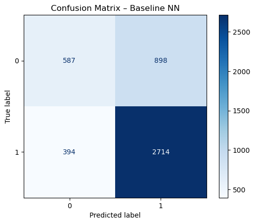

```python
cm_base = confusion_matrix(y_test, y_pred_base)
disp_base = ConfusionMatrixDisplay(cm_base, display_labels=[0,1])
disp_base.plot(cmap='Blues')
plt.title("Confusion Matrix – Baseline NN")
plt.show()
```

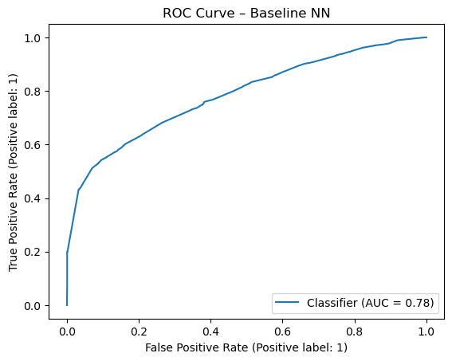

```python
RocCurveDisplay.from_predictions(y_test, y_proba_base)
plt.title("ROC Curve – Baseline NN")
plt.show()
```

##### 2.2.4.2 Parameter Tuning

```python
val_size = int(0.1 * len(X_train_selected))
X_val = X_train_selected[:val_size]
y_val = y_train[:val_size]
X_tune = X_train_selected[val_size:]
y_tune = y_train[val_size:]
```

```python
def train_nn(X_train, y_train, X_val, y_val,
             neurons=32, learning_rate=0.001,
             batch_size=32, activation='relu',
             optimizer_type='adam', epochs=30):

    model = Sequential([
        Dense(neurons, activation=activation, input_shape=(X_train.shape[1],)),
        Dense(neurons, activation=activation),
        Dense(1, activation='sigmoid')
    ])

    if optimizer_type == 'adam':
        optimizer = Adam(learning_rate=learning_rate)
    elif optimizer_type == 'sgd':
        optimizer = SGD(learning_rate=learning_rate)
    else:
        raise ValueError("Unsupported optimizer.")

    model.compile(optimizer=optimizer, loss='binary_crossentropy', metrics=['accuracy'])

    history = model.fit(
        X_train, y_train,
        validation_data=(X_val, y_val),
        epochs=epochs,
        batch_size=batch_size,
        verbose=0
    )
    return history
```

```python
#I am doing parameter selection for the neural network by storing the best values in a dictionary
tuning_results = {}
# 1. Number of neurons
for n in [16, 32, 64, 128]:
    tuning_results[f'neurons_{n}'] = train_nn(X_tune, y_tune, X_val, y_val, neurons=n)
```

```python
#Learning Rate
for lr in [0.01, 0.005, 0.001, 0.0005, 0.0001]:
    tuning_results[f'lr_{lr}'] = train_nn(X_tune, y_tune, X_val, y_val, learning_rate=lr)
```

```python
#Batch size
for b in [16, 32, 64]:
    tuning_results[f'batch_{b}'] = train_nn(X_tune, y_tune, X_val, y_val, batch_size=b)
```

```python
#Activation function
for act in ['relu', 'tanh']:
    tuning_results[f'activation_{act}'] = train_nn(X_tune, y_tune, X_val, y_val, activation=act)
```

```python
# 5. Optimizer
for opt in ['adam', 'sgd']:
    tuning_results[f'optimizer_{opt}'] = train_nn(X_tune, y_tune, X_val, y_val, optimizer_type=opt)
```

```python
def plot_tuning(tuning_results, keyword, label):
    plt.figure(figsize=(8, 5))
    for key, hist in tuning_results.items():
        if keyword in key:
            plt.plot(hist.history['val_accuracy'], label=key)
    plt.title(f'Validation Accuracy by {label}')
    plt.xlabel('Epochs')
    plt.ylabel('Validation Accuracy')
    plt.legend()
    plt.grid(True)
    plt.tight_layout()
    plt.show()
```

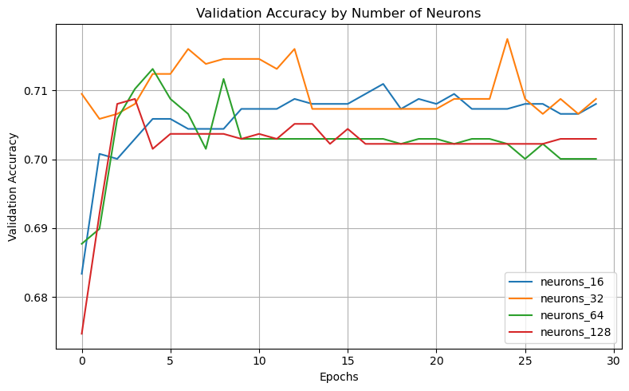

```python
plot_tuning(tuning_results, 'neurons_', 'Number of Neurons')
```

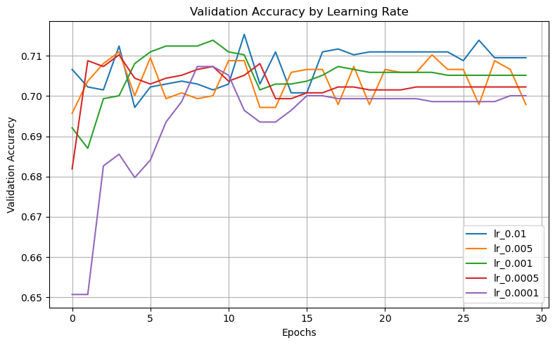

```python
plot_tuning(tuning_results, 'lr_', 'Learning Rate')
```

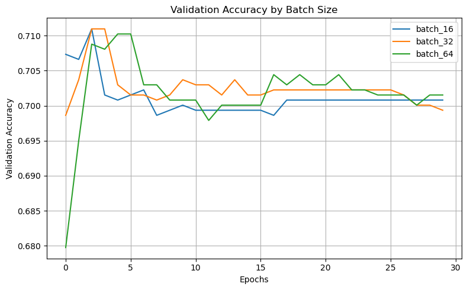

```python
plot_tuning(tuning_results, 'batch_', 'Batch Size')
```

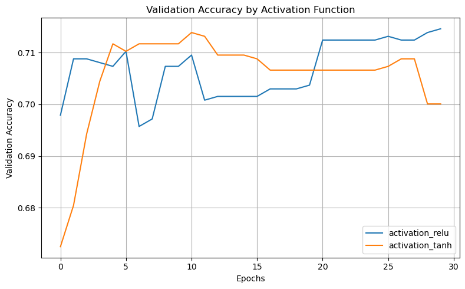

```python
plot_tuning(tuning_results, 'activation_', 'Activation Function')
```

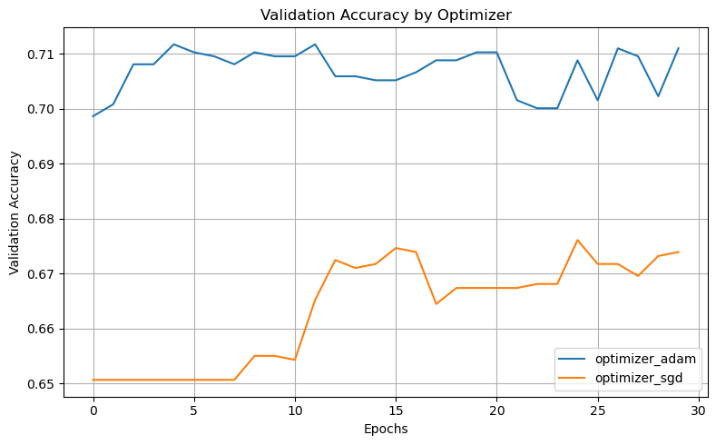

```python
plot_tuning(tuning_results, 'optimizer_', 'Optimizer')
```

```python
#Defining model based on the obtained tuned parameters
model = Sequential([
    Dense(64, activation='tanh', input_shape=(X_train_selected.shape[1],)),
    Dropout(0.2),
    Dense(1, activation='sigmoid')
])
```

```python
optimizer = Adam(learning_rate=0.001)
model.compile(optimizer=optimizer, loss='binary_crossentropy', metrics=['accuracy'])
```

```python
#Training Model
history = model.fit(
    X_train_selected, y_train,
    epochs=30,
    batch_size=64,
    validation_split=0.1,
    verbose=1
)
```

```
194/194 ━━━━━━━━━━━━━━━━━━━━ 0s 690us/step - accuracy: 0.6643 - loss: 0.6030 - val_accuracy: 0.6778 - val_loss: 0.5446
194/194 ━━━━━━━━━━━━━━━━━━━━ 0s 446us/step - accuracy: 0.6949 - loss: 0.5439 - val_accuracy: 0.7032 - val_loss: 0.5396
194/194 ━━━━━━━━━━━━━━━━━━━━ 0s 437us/step - accuracy: 0.6960 - loss: 0.5355 - val_accuracy: 0.7155 - val_loss: 0.5370
194/194 ━━━━━━━━━━━━━━━━━━━━ 0s 444us/step - accuracy: 0.7011 - loss: 0.5335 - val_accuracy: 0.7126 - val_loss: 0.5350
194/194 ━━━━━━━━━━━━━━━━━━━━ 0s 464us/step - accuracy: 0.7029 - loss: 0.5310 - val_accuracy: 0.7126 - val_loss: 0.5331
194/194 ━━━━━━━━━━━━━━━━━━━━ 0s 456us/step - accuracy: 0.7082 - loss: 0.5286 - val_accuracy: 0.7126 - val_loss: 0.5302
194/194 ━━━━━━━━━━━━━━━━━━━━ 0s 457us/step - accuracy: 0.7044 - loss: 0.5279 - val_accuracy: 0.7141 - val_loss: 0.5276
194/194 ━━━━━━━━━━━━━━━━━━━━ 0s 451us/step - accuracy: 0.7057 - loss: 0.5256 - val_accuracy: 0.7141 - val_loss: 0.5247
194/194 ━━━━━━━━━━━━━━━━━━━━ 0s 446us/step - accuracy: 0.7029 - loss: 0.5227 - val_accuracy: 0.7148 - val_loss: 0.5223
194/194 ━━━━━━━━━━━━━━━━━━━━ 0s 445us/step - accuracy: 0.7077 - loss: 0.5183 - val_accuracy: 0.7126 - val_loss: 0.5199
194/194 ━━━━━━━━━━━━━━━━━━━━ 0s 454us/step - accuracy: 0.7026 - loss: 0.5189 - val_accuracy: 0.7155 - val_loss: 0.5177
194/194 ━━━━━━━━━━━━━━━━━━━━ 0s 459us/step - accuracy: 0.6983 - loss: 0.5189 - val_accuracy: 0.7148 - val_loss: 0.5160
194/194 ━━━━━━━━━━━━━━━━━━━━ 0s 456us/step - accuracy: 0.7018 - loss: 0.5181 - val_accuracy: 0.7148 - val_loss: 0.5149
194/194 ━━━━━━━━━━━━━━━━━━━━ 0s 456us/step - accuracy: 0.7068 - loss: 0.5123 - val_accuracy: 0.7068 - val_loss: 0.5134
194/194 ━━━━━━━━━━━━━━━━━━━━ 0s 454us/step - accuracy: 0.7111 - loss: 0.5095 - val_accuracy: 0.7039 - val_loss: 0.5119
194/194 ━━━━━━━━━━━━━━━━━━━━ 0s 452us/step - accuracy: 0.7055 - loss: 0.5125 - val_accuracy: 0.7075 - val_loss: 0.5112
194/194 ━━━━━━━━━━━━━━━━━━━━ 0s 502us/step - accuracy: 0.7126 - loss: 0.5128 - val_accuracy: 0.7068 - val_loss: 0.5103
194/194 ━━━━━━━━━━━━━━━━━━━━ 0s 451us/step - accuracy: 0.7118 - loss: 0.5091 - val_accuracy: 0.7054 - val_loss: 0.5106
194/194 ━━━━━━━━━━━━━━━━━━━━ 0s 452us/step - accuracy: 0.7041 - loss: 0.5100 - val_accuracy: 0.7061 - val_loss: 0.5095
194/194 ━━━━━━━━━━━━━━━━━━━━ 0s 449us/step - accuracy: 0.7064 - loss: 0.5111 - val_accuracy: 0.7054 - val_loss: 0.5093
194/194 ━━━━━━━━━━━━━━━━━━━━ 0s 501us/step - accuracy: 0.7121 - loss: 0.5076 - val_accuracy: 0.7032 - val_loss: 0.5090
194/194 ━━━━━━━━━━━━━━━━━━━━ 0s 497us/step - accuracy: 0.7102 - loss: 0.5106 - val_accuracy: 0.7054 - val_loss: 0.5085
194/194 ━━━━━━━━━━━━━━━━━━━━ 0s 465us/step - accuracy: 0.7100 - loss: 0.5068 - val_accuracy: 0.7032 - val_loss: 0.5081
194/194 ━━━━━━━━━━━━━━━━━━━━ 0s 455us/step - accuracy: 0.7085 - loss: 0.5060 - val_accuracy: 0.7032 - val_loss: 0.5079
194/194 ━━━━━━━━━━━━━━━━━━━━ 0s 460us/step - accuracy: 0.7064 - loss: 0.5093 - val_accuracy: 0.7054 - val_loss: 0.5086
194/194 ━━━━━━━━━━━━━━━━━━━━ 0s 530us/step - accuracy: 0.7110 - loss: 0.5052 - val_accuracy: 0.7032 - val_loss: 0.5081
194/194 ━━━━━━━━━━━━━━━━━━━━ 0s 498us/step - accuracy: 0.7110 - loss: 0.5073 - val_accuracy: 0.7032 - val_loss: 0.5083
194/194 ━━━━━━━━━━━━━━━━━━━━ 0s 481us/step - accuracy: 0.7053 - loss: 0.5067 - val_accuracy: 0.7054 - val_loss: 0.5080
194/194 ━━━━━━━━━━━━━━━━━━━━ 0s 498us/step - accuracy: 0.7099 - loss: 0.5064 - val_accuracy: 0.7032 - val_loss: 0.5079
194/194 ━━━━━━━━━━━━━━━━━━━━ 0s 537us/step - accuracy: 0.7156 - loss: 0.5038 - val_accuracy: 0.7032 - val_loss: 0.5074
```

```python
y_pred_proba = model.predict(X_test_selected).flatten()
y_pred = (y_pred_proba >= 0.5).astype(int)
```

```
144/144 ━━━━━━━━━━━━━━━━━━━━ 0s 341us/step
```

```python
print("\n Classification Report (Neural Network):")
print(classification_report(y_test, y_pred))
```

```
 Classification Report (Neural Network):
              precision    recall  f1-score   support

           0       0.59      0.30      0.39      1485
           1       0.73      0.90      0.81      3108

    accuracy                           0.71      4593
   macro avg       0.66      0.60      0.60      4593
weighted avg       0.68      0.71      0.67      4593
```

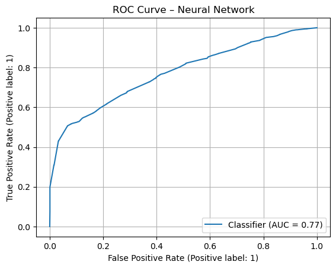

```python
RocCurveDisplay.from_predictions(y_test, y_pred_proba)
plt.title("ROC Curve – Neural Network")
plt.grid(True)
plt.show()
```

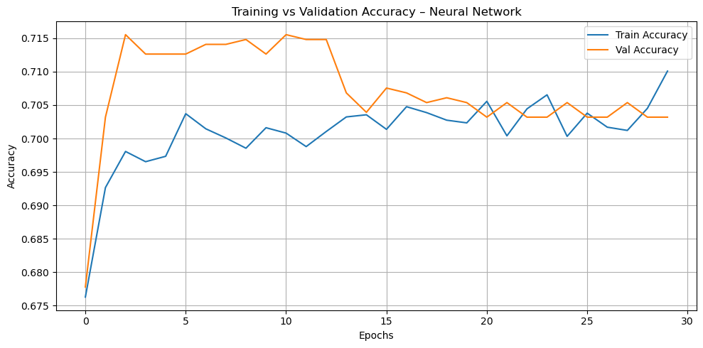

```python
plt.figure(figsize=(10, 5))
plt.plot(history.history['accuracy'], label='Train Accuracy')
plt.plot(history.history['val_accuracy'], label='Val Accuracy')
plt.xlabel("Epochs")
plt.ylabel("Accuracy")
plt.title("Training vs Validation Accuracy – Neural Network")
plt.legend()
plt.grid(True)
plt.tight_layout()
plt.show()
```

To evaluate the performance of deep learning models for daytime occupancy prediction, I built and fine-tuned a feedforward neural network using Keras/TensorFlow. My goal was to prioritize recall for class 1 (`IsHomeDaytime = 1`) — identifying when someone is at home during the day — which aligns with the broader objective of supporting intelligent energy management systems.

##### Baseline Neural Network Architecture

My baseline neural network consisted of two fully connected dense layers:

```
Dense(32, activation='relu') → Dense(16, activation='relu') → Dense(1, activation='sigmoid')
```

##### Hyperparameter Tuning Strategy

To improve the model’s balance and generalization, I conducted a systematic grid search across five key hyperparameters. For each configuration, I trained the model on a training split (90%) and validated it on a reserved 10% validation set. The following hyperparameters were tuned independently:

- **Number of Neurons per Layer**: [16, 32, 64, 128]
- **Learning Rate**: [0.01, 0.005, 0.001, 0.0005, 0.0001]
- **Batch Size**: [16, 32, 64]
- **Activation Function**: `relu`, `tanh`
- **Optimizer**: `adam`, `sgd`

##### Final Neural Network Configuration

```
Dense(64, activation='tanh') → Dropout(0.2) → Dense(1, activation='sigmoid')
```

This network was trained with:

- **Optimizer**: Adam with learning rate = 0.001
- **Epochs**: 30
- **Batch Size**: 64
- **Loss Function**: Binary Cross-Entropy
- **Dropout**: 0.2 to reduce overfitting

Training was conducted on the entire training dataset (`X_train_selected`, `y_train`) with a 10% validation split.

### 2.3 Model Comparison (using t-test)

```python
cv     = StratifiedKFold(n_splits=5, shuffle=True, random_state=42)
scorer = make_scorer(roc_auc_score, needs_proba=True)
logreg = LogisticRegression( penalty='l2', solver='lbfgs',
                             max_iter=1000, random_state=42 )

knn    = KNeighborsClassifier(n_neighbors=20, p=2, weights='uniform')

rf     = RandomForestClassifier(n_estimators=200, max_depth=10,
                                min_samples_split=2, random_state=42)

nn     = MLPClassifier(hidden_layer_sizes=(64,),
                       activation='tanh',
                       solver='adam',
                       learning_rate_init=0.001,
                       batch_size=64,
                       max_iter=200,
                       random_state=42)

scores_log = cross_val_score(logreg, X_train_selected, y_train, cv=cv, scoring=scorer)
scores_knn = cross_val_score(knn,   X_train_selected, y_train, cv=cv, scoring=scorer)
scores_rf  = cross_val_score(rf,    X_train_selected, y_train, cv=cv, scoring=scorer)
scores_nn  = cross_val_score(nn,    X_train_selected, y_train, cv=cv, scoring=scorer)
```

```python
comparisons = [
    ("Logistic vs KNN",        scores_log, scores_knn),
    ("Logistic vs RandomForest",scores_log, scores_rf),
    ("Logistic vs NeuralNet",   scores_log, scores_nn),
    ("KNN vs RandomForest",     scores_knn, scores_rf),
    ("KNN vs NeuralNet",        scores_knn, scores_nn),
    ("RandomForest vs NeuralNet",scores_rf,   scores_nn)
]

for label, s1, s2 in comparisons:
    t_stat = ttest_rel(s1, s2).statistic
    print(f"{label}: t-stat = {t_stat:.3f}")
```

```
Logistic vs KNN: t-stat = -4.313
Logistic vs RandomForest: t-stat = -6.535
Logistic vs NeuralNet: t-stat = -7.235
KNN vs RandomForest: t-stat = -17.986
KNN vs NeuralNet: t-stat = -19.852
RandomForest vs NeuralNet: t-stat = -14.151
```

All six pairwise t-tests produced t-statistics far beyond the critical threshold (**|t| ≫ 2.78** for 4 df at **α = 0.05**), confirming statistically significant differences in mean ROC-AUC between every pair of models. Specifically, Logistic Regression was outperformed by KNN (**t = –4.313**), Random Forest (**t = –6.535**), and the Neural Network (**t = –7.235**); KNN was outperformed by Random Forest (**t = –17.986**) and the Neural Network (**t = –19.852**); and Random Forest was outperformed by the Neural Network (**t = –14.151**). Consequently, the ordering of mean cross-validated ROC-AUC is **Logistic Regression < KNN < Random Forest < Neural Network**, with each step in this sequence reflecting a statistically significant improvement in predictive discrimination for daytime occupancy.

## Task 3 Critique and Limitations

Reflecting on the work completed across both phases, I recognize several strengths in my approach, as well as a few limitations that could be improved with more time, resources, or domain knowledge.

#### Strengths

One of the main strengths of this project is the **structured and reproducible methodology** I followed. From systematic feature engineering to consistent cross-validation and ROC-AUC-based model evaluation, each step was designed to balance rigor with clarity. For instance, the use of **`SelectKBest` (ANOVA F-test)** ensured only statistically relevant features were retained. This prevented overfitting while keeping the model interpretable.

Another strength is the **model variety and depth of tuning**. I didn’t rely on a single model or hyperparameter setting. Instead, I explored logistic regression (with and without regularization), several versions of KNN, random forests with an extensive grid, and a neural network that underwent **fine-tuning over five hyperparameters**. This helped me better understand how each model reacts to imbalanced data and feature space constraints.

#### Limitations

Another limitation is that **feature interaction effects weren’t fully explored**. Although I used one-hot and ordinal encoding effectively, I didn’t engineer combination features (e.g., `HasAircon + HasInternet`) that could capture more nuanced behaviors. Including such interaction terms might have improved model performance, especially for harder-to-predict “not at home” instances.

In addition, while the neural network was tuned extensively, the final model could benefit from **cross-validated training** or ensemble methods. I trained and validated on fixed splits, which, although common in deep learning workflows, can be less stable than using stratified k-fold CV for NN performance evaluation.

Lastly, I recognize that **domain-specific insights** were somewhat limited. For example, how strongly should `NumFridges` or `GasUse` correlate with occupancy in different climate zones? A closer collaboration with energy researchers or access to time-series usage patterns could make the feature set more meaningful.

#### Personal Reflection

This project taught me a lot about the **trade-offs between accuracy, interpretability, and business value**. In real-world deployments, getting every prediction right is less important than optimizing for the most meaningful outcomes — in this case, reducing false negatives for class 1. I’m proud of the results achieved, but I’m also aware of how iterative and evolving good modeling practice needs to be.

## Task 4

#### Task 4.1 Project Summary

This project aimed to develop a predictive model that accurately identifies whether a household is occupied during the daytime, supporting smarter energy management. In **Phase 1**, I began by cleaning the dataset, addressing missing values, and transforming categorical and ordinal features. I used **ordinal encoding** for usage-level variables like `GasUse` and **one-hot encoding** for nominal features such as `ClimateZone`, `UnitType`, etc.

Next, I developed and fine-tuned a **Neural Network model** using Keras/TensorFlow. I tuned five key hyperparameters (number of neurons, learning rate, batch size, activation function, and optimizer), plotted **validation accuracy curves**, and selected the best-performing configuration.

#### Task 4.3 Conclusions

The project successfully developed a robust predictive pipeline capable of identifying daytime home occupancy with a high degree of accuracy and recall. This is particularly valuable in applications such as **smart thermostats, lighting control systems**, or **energy-saving devices**, where correctly identifying when someone is home is more important than predicting absence.

The systematic tuning, validation, and statistical testing framework I used ensured the results are both **data-driven and statistically sound**. The key trade-off — lower recall for class 0 in exchange for high recall for class 1 — is acceptable in the domain context where **false negatives are costlier than false positives**.

Overall, the project met its objectives, and the methods used can be adapted to similar classification problems in smart grid systems, IoT home automation, and beyond.

## References

[1] RMIT University. (n.d.). Week 4 Practical. RMIT Canvas. https://rmit.instructure.com/courses/141207/pages/week-4-practical?module_item_id=7224068

[2] RMIT University. (n.d.). Week 5 Practical. RMIT Canvas. https://rmit.instructure.com/courses/141207/pages/week-5-practical?module_item_id=7232140

[3] RMIT University. (n.d.). Week 6 Practical. RMIT Canvas. https://rmit.instructure.com/courses/141207/pages/week-6-practical?module_item_id=7250280

[4] RMIT University. (n.d.). Week 7 Practical. RMIT Canvas. https://rmit.instructure.com/courses/141207/pages/week-7-practical?module_item_id=7277223

[5] RMIT University. (n.d.). Week 8 Practical. RMIT Canvas. https://rmit.instructure.com/courses/141207/pages/week-8-practical?module_item_id=7292466

[6] RMIT University. (n.d.). Week 10 Practical. RMIT Canvas. https://rmit.instructure.com/courses/141207/pages/week-10-practical?module_item_id=7319152